```python
import sys
sys.path.append('..')
import numpy as np
import scipy.stats
import matplotlib
import matplotlib.pyplot as plt

matplotlib.style.use('ggplot')
%matplotlib inline
```

# Inference with ELFI: the MA(3) model

The 3rd order moving average model, MA(3) $$ y_t = w_t + \theta_1 w_{t-1} + \theta_2 w_{t-2} + \theta_3 w_{t-3}, $$ Where $ \theta_1 ,\theta_2,\theta_3 $ are parameters and w is iid white noise.

```python
def MA2(t1,t2,t3, batch_size=1, random_state=None):
    n_obs = 500
    if random_state is None:
        random_state = np.random.RandomState()
    w = random_state.randn(batch_size, n_obs+3) # i.i.d. sequence ~ N(0,1)
    y = w[:,3:] + t1 * w[:,2:-1] + t2 * w[:,1:-2] + t3 *w[:,:-3]
    return y
```

The task is to infer three parameters t1,t2,t3 from 500 observations from MA(3) model defined above.

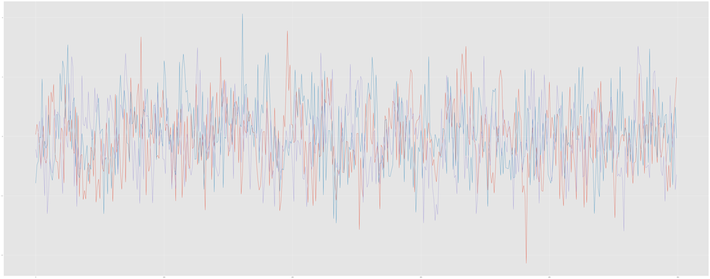

```python
# true parameters
t1_0 = .2
t2_0 = .3
t3_0 = .4
# Set up observed data y with some random seed
random_state = np.random.RandomState(20170425)
y = MA2(t1_0, t2_0, t3_0, random_state=random_state)

# Plot the observed sequence
plt.figure(figsize=(100, 40));
plt.plot(y.flatten());

# To illustrate the stochasticity draw few more plots using true parameters
plt.plot(MA2(t1_0, t2_0 , t3_0).flatten());
plt.plot(MA2(t1_0, t2_0 , t3_0).flatten());
```

## Approximate Bayesian Computation

We are going to use elfi engine for Approximate Bayesian Computation also known as likelihood free inference to estimate parameters. First, we need to define priors for these three parameters as nodes having parents (0,2), assuming that they follow uniform(0,2).

```python
import elfi

# a node is defined by giving it a name, a distribution
# from scipy.stats and its parents
t1 = elfi.Prior('t1', scipy.stats.uniform, 0, 2)

t2 = elfi.Prior('t2', 'uniform', 0, 2)

t3 = elfi.Prior('t3', 'uniform', 0, 2 )
```

Now we would define simulator node with prior nodes as parents.

```python
Y = elfi.Simulator('MA2', MA2, t1, t2, t3, observed=y)
```

Now we would define autocovariances with lags 1, 2 and 3 as the summary statistics. After that we would calculate the distance using Euclidean L2-distanc.

```python
def autocov(x, lag=1):
    mu = np.mean(x, axis=1, keepdims=True)
    C = np.mean(x[:,lag:] * x[:,:-lag], axis=1, keepdims=True) - mu**2.
    return C

def distance(x, y):
    d = np.linalg.norm( np.array(x) - np.array(y), ord=2, axis=0)
    return d
```

Defining summery nodes with autocovariances and observed data as parents.

```python
S1 = elfi.Summary('S1', autocov, Y)
```

```python
from functools import partial

autocov2 = partial(autocov, lag=2)

S2 = elfi.Summary('S2', autocov2, Y)
```

```python
from functools import partial
autocov3 = partial(autocov, lag=3)

S3 = elfi.Summary('S3', autocov3, Y)
```

Similarly, defining distance node with summery statistic parents.

```python
d = elfi.Discrepancy('d', distance, S1, S2, S3)
```

Redefining priors with ranges [-b, b],[-a,a],[-c,c]

```python
class MarinPrior_t1(elfi.Distribution):
    def rvs(b, size=1, random_state=None):
        u = scipy.stats.uniform.rvs(loc=0, scale=1, size=size, random_state=random_state)
        t1 = np.where(u<0.5, np.sqrt(2.*u)*b-b, -np.sqrt(2.*(1.-u))*b+b)
        return t1

# define prior for t2 conditionally on t1 as in Marin et al., 2012, in range [-a, a]
class MarinPrior_t2(elfi.Distribution):
    def rvs(t1, a, size=1, random_state=None):
        locs = np.maximum(-a-t1, t1-a)
        scales = a - locs
        t2 = scipy.stats.uniform.rvs(loc=locs,scale=scales,size=size,random_state=random_state)
        return t2
class MarinPrior_t3(elfi.Distribution):
    def rvs(t1, c, size=1, random_state=None):
        locs = np.maximum(-c-t1, t1-c)
        scales = c - locs
        t3 = scipy.stats.uniform.rvs(loc=locs,scale=scales,size=size,random_state=random_state)
        return t3
```

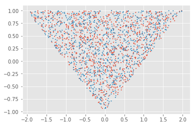

```python
t1_1000 = MarinPrior_t1.rvs(2, 1000)
t2_1000 = MarinPrior_t2.rvs(t1_1000, 1, 1000)
t3_1000 = MarinPrior_t3.rvs(t1_1000, 1, 1000)

plt.scatter(t1_1000, t2_1000, s=4, edgecolor='none');
plt.scatter(t1_1000, t3_1000, s=4, edgecolor='none');
```

### Inferencee Model:

```python
t1.redefine(MarinPrior_t1, 2)
t2.redefine(MarinPrior_t2, t1, 1)
t3.redefine(MarinPrior_t3, t1, 1)
elfi.draw_model(d)
```

[figure not shown]

### inference with rejection sampling

```python
rej = elfi.Rejection(d, [t1, t2, t3], batch_size=10000)
rej = elfi.Rejection(d, [t1, t2, t3], batch_size=10000)
```

```python
N = 10000
%time result = rej.sample(N, quantile=0.01)
```

```
elfi.methods - INFO - Rejection: Running with 1000000 proposals.
```

```
CPU times: user 48.4 s, sys: 12.9 s, total: 1min 1s
Wall time: 25.6 s
```

```python
result.summary()
```

```
Method: Rejection
Number of posterior samples: 10000
Number of simulations: 1000000
Threshold: 0.235
Posterior means: t1: 0.328, t2: 0.257, t3: 0.479
```

```python
%time result2 = rej.sample(N, threshold=0.2)

print(result2)
```

```
elfi.methods - INFO - Rejection: Running with 10000 proposals.
elfi.methods - INFO - Rejection: Running with 1890000 proposals.
```

```
CPU times: user 1min 30s, sys: 22.1 s, total: 1min 52s
Wall time: 41 s
Method: Rejection
Number of posterior samples: 10000
Number of simulations: 1890000
Threshold: 0.2
Posterior means: t1: 0.31, t2: 0.273, t3: 0.474
```

```python
%time result3 = rej.reject(threshold=0.3)

result3
```

```
elfi.methods - INFO - Rejection: Running with 1890000 proposals.
```

```
CPU times: user 1min 31s, sys: 22.4 s, total: 1min 53s
Wall time: 42.4 s
```

```
Method: Rejection
Number of posterior samples: 39070
Number of simulations: 1890000
Threshold: 0.3
Posterior means: t1: 0.349, t2: 0.239, t3: 0.482
```

### Plotting of results

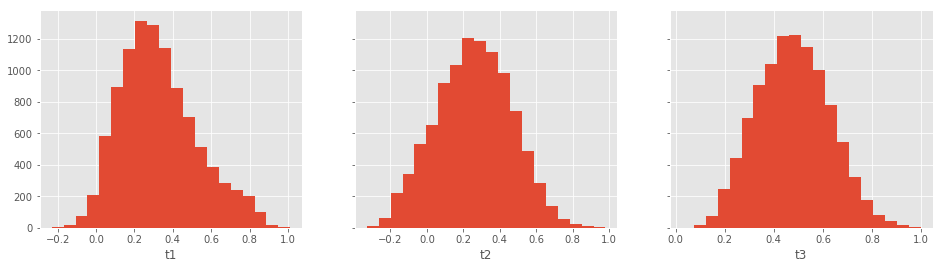

```python
result.plot_marginals();
```

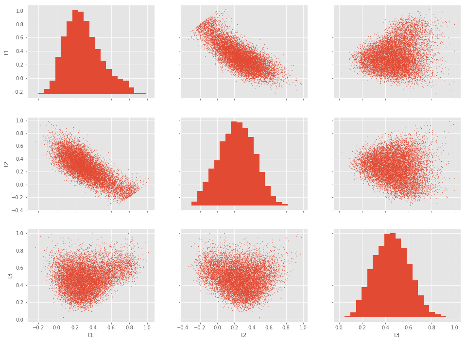

```python
result.plot_pairs();
```

## Inference with Sequential Monti Calro

Redefining priors for SMC.

```python
class MarinPrior_t1(elfi.Distribution):
    def rvs(b, size=1, random_state=None):
        u = scipy.stats.uniform.rvs(loc=0, scale=1, size=size, random_state=random_state)
        t1 = np.where(u<0.5, np.sqrt(2.*u)*b-b, -np.sqrt(2.*(1.-u))*b+b)
        return t1

    def pdf(x, b):
        p = 1./b - np.abs(x) / (b*b)
        p = np.where(p < 0., 0., p)
        return p


class MarinPrior_t2(elfi.Distribution):
    def rvs(t1, a, size=1, random_state=None):
        locs = np.maximum(-a-t1, t1-a)
        scales = a - locs
        t2 = scipy.stats.uniform.rvs(loc=locs,scale=scales,size=size,random_state=random_state)
        return t2

    def pdf(x, t1, a):
        locs = np.maximum(-a-t1, t1-a)
        scales = a - locs
        p = scipy.stats.uniform.pdf(x, loc=locs, scale=scales)
        p = np.where(scales>0., p, 0.)
        return p

class MarinPrior_t3(elfi.Distribution):
    def rvs(t1, a, size=1, random_state=None):
        locs = np.maximum(-a-t1, t1-a)
        scales = a - locs
        t2 = scipy.stats.uniform.rvs(loc=locs,scale=scales,size=size,random_state=random_state)
        return t2

    def pdf(x, t1, c):
        locs = np.maximum(-c-t1, t1-c)
        scales = c - locs
        p = scipy.stats.uniform.pdf(x, loc=locs, scale=scales)
        p = np.where(scales>0., p, 0.)
        return p

# Redefine the priors
t1.redefine(MarinPrior_t1, 2)
t2.redefine(MarinPrior_t2, t1, 1)
t3.redefine(MarinPrior_t3, t1, 1)
```

```python
smc = elfi.SMC(d, [t1, t2, t3], batch_size=10000)
```

```python
N = 1000
n_populations = 3
schedule = [0.7, 0.2, 0.05]
%time result_smc = smc.sample(N, n_populations, schedule)
```

[output not shown]

[output cut: 455 more lines]

[output not shown]

```
CPU times: user 1min 10s, sys: 8.25 s, total: 1min 18s
Wall time: 2min 23s
```

```python
result_smc.summary()
```

[output not shown]

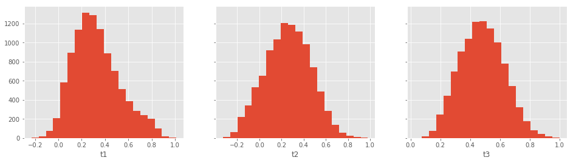

```python
result.plot_marginals();
```

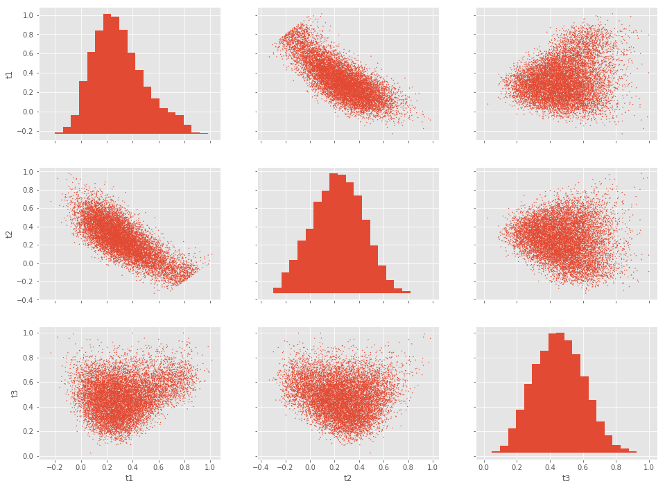

```python
result.plot_pairs();
```